# Vamos investir no próximo sucesso de Hollywood?

```r
library(tidyverse)
library(ggplot2)
library(knitr)
```

## Entendendo o que vem pela frente

Esse relatório vai te dar as informaçoes básicas para produzir o mais novo sucesso da indústria cinematográfica. Veremos que tipo de filme produzir, que diretor contratar e que diretores NÃO contratar, que atores são vilões de bilheteria e de crítica.

A partir de uma base com 3713 filmes analisados vamos apresentar alguns resultados para uma tomada de decisão mais eficiente, já que investir em filme não é certeza de lucro:

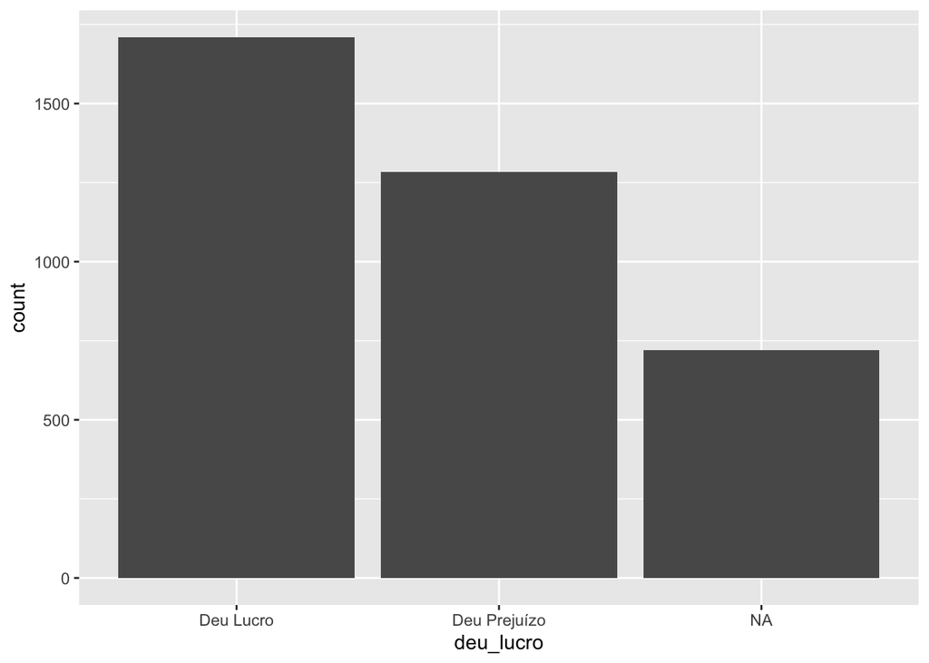

Além do sucesso financeiro, queremos também que seu investimento seja um sucesso de crítica e nessa área a coisa fica mais complicada, pois como vemos no gráfico abaixo, a maior parte dos filmes obteve notas abaixo de 8.

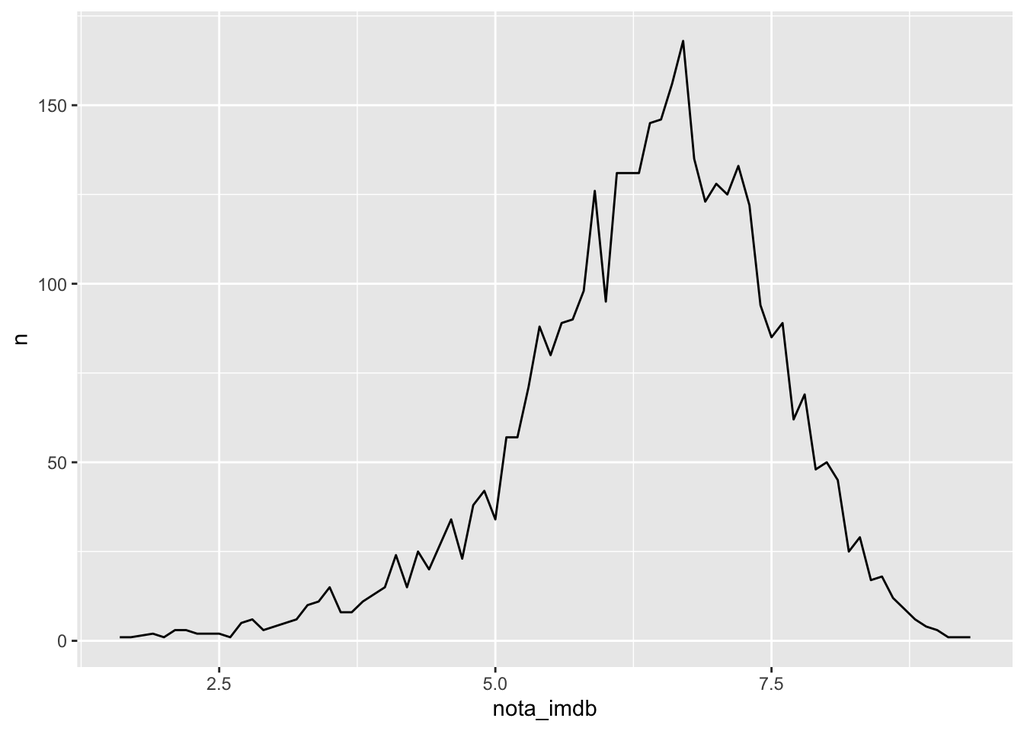

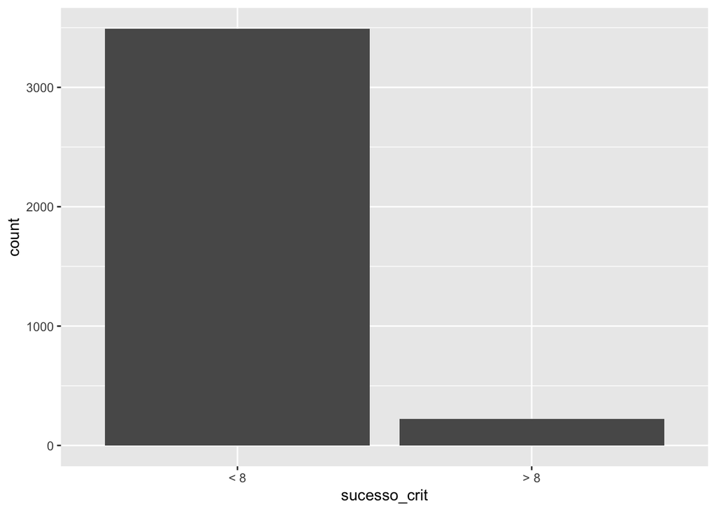

## Vamor investir num sucesso de bilheteria e de críticas?

Para isso vamos começar escolhendo que tipo de filme vamos fazer:

Os 10 maiores sucesso de bilheteria segundo o gênero

| generos | mediana_nota | mediana_lucro |
| --- | --- | --- |
| Family\|Sci-Fi | 5.65 | 424449459 |
| Adventure\|Animation\|Drama\|Family\|Musical | 8.50 | 377783777 |
| Action\|Biography\|Drama\|History\|Thriller\|War | 7.30 | 291323553 |
| Adventure\|Drama\|Fantasy\|Romance | 4.90 | 232523113 |
| Action\|Adventure\|Fantasy\|Sci-Fi | 7.20 | 231469069 |
| Drama\|Fantasy\|Romance\|Thriller | 7.00 | 195631306 |
| Drama\|History\|Romance\|War | 7.20 | 194678278 |
| Adventure\|Animation\|Comedy\|Drama\|Family\|Fantasy | 8.30 | 181454367 |
| Action\|Adventure\|Fantasy\|Romance | 7.30 | 173377893 |
| Action\|Adventure\|Animation\|Family | 8.00 | 169437578 |

| generos | mediana_nota | mediana_lucro |
| --- | --- | --- |
| Adventure\|Animation\|Drama\|Family\|Musical | 8.5 | 377783777 |
| Adventure\|Animation\|Comedy\|Drama\|Family\|Fantasy | 8.3 | 181454367 |
| Crime\|Drama\|Fantasy\|Mystery | 8.5 | 76801374 |
| Adventure\|Drama\|War | 8.3 | 45523073 |
| Biography\|Drama\|History\|Music | 8.3 | 33600000 |
| Documentary\|Drama\|Sport | 8.3 | 7130611 |
| Action\|Adventure\|Biography\|Drama\|History | 8.6 | NA |
| Action\|Adventure\|Crime\|Drama\|Sci-Fi\|Thriller | 8.8 | NA |
| Action\|Animation\|Crime\|Sci-Fi\|Thriller | 8.4 | NA |
| Adventure\|Drama\|History\|Thriller\|War | 8.3 | NA |
| Comedy\|Mystery\|Thriller | 8.3 | NA |